# Spookey Authorship Identification with Apache Spark

## Import Libraries

Import the libraries we will need for this assignment.

```python
import nltk
import matplotlib.pyplot as plt

from nltk.stem import WordNetLemmatizer
from pyspark.ml import Pipeline
from pyspark.ml.classification import (
    NaiveBayes,
)

from pyspark.ml.evaluation import (
    MulticlassClassificationEvaluator,
)
from pyspark.ml.feature import (
    CountVectorizer,
    IDF,
    Normalizer,
    StopWordsRemover,
    StringIndexer,
    VectorAssembler,
)
from pyspark.ml.stat import Correlation
from pyspark.mllib.evaluation import MulticlassMetrics
from pyspark.sql import SparkSession
from pyspark.sql.functions import (
    col,
    count,
    regexp_replace,
    row_number,
    udf,
)
from pyspark.sql.types import ArrayType, StringType
from pyspark.sql.window import Window
import seaborn as sns
# Create Spark session
spark = SparkSession.builder\
    .getOrCreate()
# Set the logging level to ERROR
spark.sparkContext.setLogLevel("ERROR")
nltk.download('wordnet', quiet=True)
```

```
True
```

## M5- Stage 0 Load the Data

```python
data = spark.builder \
    .appName("SpookyAuthorIdentification") \
    .getOrCreate()

train_data = spark.read.csv(
    "train.csv",
    escape='"',
    header=True,
    inferSchema=True,
)
```

### Initial quick look at the data

```python
print("Train data schema:")
train_data.printSchema()
print("\nTrain data row sample:")
train_data.show(10)
print(f"\nNumber of rows in train_data: {train_data.count()}")
print("\nUnique authors in train_data:")
train_data.groupBy("author").count().show()
```

```
Train data schema:
root
 |-- id: string (nullable = true)
 |-- text: string (nullable = true)
 |-- author: string (nullable = true)


Train data row sample:
+-------+--------------------+------+
|     id|                text|author|
+-------+--------------------+------+
|id26305|This process, how...|   EAP|
|id17569|It never once occ...|   HPL|
|id11008|In his left hand ...|   EAP|
|id27763|How lovely is spr...|   MWS|
|id12958|Finding nothing e...|   HPL|
|id22965|A youth passed in...|   MWS|
|id09674|The astronomer, p...|   EAP|
|id13515|The surcingle hun...|   EAP|
|id19322|I knew that you c...|   EAP|
|id00912|I confess that ne...|   MWS|
+-------+--------------------+------+
only showing top 10 rows


Number of rows in train_data: 19579

Unique authors in train_data:
+------+-----+
|author|count|
+------+-----+
|   MWS| 6044|
|   HPL| 5635|
|   EAP| 7900|
+------+-----+
```

## Task 1. Assignment 6

- Reverse engineer a SQL statement from PDF that can print out the author and number words credited to them in the dataset.

```python
train_data.createOrReplaceTempView("spooky_sentences")

result_df = spark.sql("""
    SELECT author, SUM(size(split(text, ' '))) AS total_words
    FROM spooky_sentences
    GROUP BY author
""")

print("SQL Results total words grouped by author:")
result_df.show()
```

```
SQL Results total words grouped by author:
+------+-----------+
|author|total_words|
+------+-----------+
|   MWS|     165710|
|   HPL|     156651|
|   EAP|     200995|
+------+-----------+
```

## Task 2 & 3. Assignment 6

- category wordy or not wordy
- Average word count per author

```python
result_df = spark.sql("""
    SELECT author, size(split(text, ' ')) AS total_words
    FROM spooky_sentences
""")

def author_category_udf(count):
    if count > 30:
        return 'wordy'
    elif count < 7:
        return 'pity'
    else:
        return 'not wordy'

classify_word_count_udf = udf(author_category_udf, StringType())

result_df = result_df.withColumn("author_category", classify_word_count_udf("total_words"))

print("Results user defined function:")
result_df.show(10, truncate=True)
```

```
Results user defined function:
+------+-----------+---------------+
|author|total_words|author_category|
+------+-----------+---------------+
|   EAP|         41|          wordy|
|   HPL|         14|      not wordy|
|   EAP|         36|          wordy|
|   MWS|         34|          wordy|
|   HPL|         27|      not wordy|
|   MWS|         83|          wordy|
|   EAP|         21|      not wordy|
|   EAP|          8|      not wordy|
|   EAP|         88|          wordy|
|   MWS|         23|      not wordy|
+------+-----------+---------------+
only showing top 10 rows
```

### Average Word Count per user

```python
average_word_count_df = spark.sql("""
    SELECT author, AVG(size(split(text, ' '))) AS average_word_count
    FROM spooky_sentences
    GROUP BY author
""")

print("Average Word Count per Author:")
average_word_count_df.show()
```

```
Average Word Count per Author:
+------+------------------+
|author|average_word_count|
+------+------------------+
|   MWS|27.417273328921244|
|   HPL|27.799645075421473|
|   EAP| 25.44240506329114|
+------+------------------+
```

## Task 4. Assignment 6

```python
result_df = spark.sql("""
    SELECT *
    FROM spooky_sentences
    WHERE size(split(text, ' ')) > 30
""")

print("Query results for author text over 30 words:")
result_df.show()
```

```
Query results for author text over 30 words:
+-------+--------------------+------+
|     id|                text|author|
+-------+--------------------+------+
|id26305|This process, how...|   EAP|
|id11008|In his left hand ...|   EAP|
|id27763|How lovely is spr...|   MWS|
|id22965|A youth passed in...|   MWS|
|id19322|I knew that you c...|   EAP|
|id12799|He had escaped me...|   MWS|
|id08441|To these speeches...|   EAP|
|id14862|I even went so fa...|   EAP|
|id20836|His facial aspect...|   HPL|
|id08075|It was not that t...|   HPL|
|id19925|With how deep a s...|   EAP|
|id02448|All that as yet c...|   EAP|
|id23451|I seemed to be up...|   EAP|
|id27907|Our compasses, de...|   HPL|
|id00764|I was rich and yo...|   MWS|
|id00683|We could make out...|   MWS|
|id19576|"The present pecu...|   EAP|
|id01577|Wilbur's growth w...|   HPL|
|id01651|Pausing, I succee...|   HPL|
|id27080|It was all mud an...|   HPL|
+-------+--------------------+------+
only showing top 20 rows
```

## M6 - Task 5 and 6

- Try block for error handling
- Lexical density function

```python
try:
    lexical_density_df = spark.sql("""
        SELECT author, AVG(size(split(text, ' '))) AS average_word_count,
            SUM(size(split(text, ' '))) AS total_word_count
        FROM spooky_sentences
        GROUP BY author
    """)

    lexical_density_df = lexical_density_df.withColumn(
        "lexical_density", lexical_density_df["average_word_count"] / lexical_density_df["total_word_count"]
    )

    print("Lexical Density per Author:")
    lexical_density_df.show()
except Exception as e:
    print(f'Error printing Lexical Density per Author: {e}')
```

```
Lexical Density per Author:
+------+------------------+----------------+--------------------+
|author|average_word_count|total_word_count|     lexical_density|
+------+------------------+----------------+--------------------+
|   MWS|27.417273328921244|          165710|1.654533421575115...|
|   HPL|27.799645075421473|          156651|1.774622892635315E-4|
|   EAP| 25.44240506329114|          200995|1.265822784810126...|
+------+------------------+----------------+--------------------+
```

## M5 - Stage 2 Data Preparation

- Create equal sized samples for each author
- Remove punctuation
- Lemmatize & Tokenize the text to it root word using NLTK and ApacheSpark
- Remove stop words

```python
# Balance the data so authors have the same number of rows
author_counts = train_data.groupBy("author").agg(count("*").alias("count"))
min_count = author_counts.agg({"count": "min"}).collect()[0][0]
authors = [row["author"] for row in author_counts.collect()]
balanced_data = spark.createDataFrame([], train_data.schema)
for author in authors:
    author_data = train_data.filter(col("author") == author).orderBy("id").limit(min_count)
    balanced_data = balanced_data.union(author_data)
print("\nBalanced rows for the author column:")
balanced_data.groupBy("author").count().show()

# Remove punctuation from the text column
balanced_data = balanced_data.withColumn("clean_text", regexp_replace(col("text"), "[^a-zA-Z0-9\s]", ""))

# Using the lemmatizer from nltk, we create tokens and lemmatize them.
lemmatizer = WordNetLemmatizer()
lemmatize_udf = udf(
    lambda text: [lemmatizer.lemmatize(token.lower()) for token in text.split()],
    ArrayType(StringType())
)
balanced_data = balanced_data.withColumn("tokens", lemmatize_udf("clean_text"))

# Remove the stop words
stop_words = StopWordsRemover.loadDefaultStopWords("english")
remover = StopWordsRemover(inputCol="tokens", outputCol="filtered_tokens", stopWords=stop_words)
balanced_data = remover.transform(balanced_data)

balanced_data.select("author", "filtered_tokens").show(truncate=False)
```

```
Balanced rows for the author column:
```

```
+------+-----+
|author|count|
+------+-----+
|   MWS| 5635|
|   HPL| 5635|
|   EAP| 5635|
+------+-----+
```

```
[Stage 84:====================================================>   (13 + 1) / 14]
```

```
+------+-----------------------------------------------------------------------------------------------------------------------------------------------------------------------------+
|author|filtered_tokens                                                                                                                                                              |
+------+-----------------------------------------------------------------------------------------------------------------------------------------------------------------------------+
|MWS   |[idris, wa, well, content, resolve, mine]                                                                                                                                    |
|MWS   |[obeyed, lord, protector, dying, england, looked]                                                                                                                            |
|MWS   |[true, wretch]                                                                                                                                                               |
|MWS   |[besieger, comparison, little, affected, evil]                                                                                                                               |
|MWS   |[thus, may, console, reducing, nothing, word, bear, soon, make, mad, quite, mad, shall, utter, strange, word, believe, shall, lost, ever]                                    |
|MWS   |[raymond, sat, among, though, entered, spirit, hour, natural, dignity, never, forsook]                                                                                       |
|MWS   |[descended, parnassus, emerging, many, fold, passed, livadia, road, attica]                                                                                                  |
|MWS   |[owned, affinity, mankind, nature, wa, akin, mountain, sky, friend, wind, heaven, offspring, earth, playmate, focus, mighty, mirror, felt, life, mingle, universe, existence]|
|MWS   |[time, passed, away, became, calm, misery, dwelling, heart, longer, talked, incoherent, manner, crime, sufficient, wa, consciousness]                                        |
|MWS   |[shall, man, enemy, man, plague, foe, even, u, triumphing, butchery, cruel]                                                                                                  |
|MWS   |[conjectured, therefore, found, paper, sign, speech, understood, ardently, longed, comprehend, also, wa, possible, even, understand, sound, stood, sign]                     |
|MWS   |[wa, joy, possessed, felt, flesh, tingle, excess, sensitiveness, pulse, beat, rapidly]                                                                                       |
|MWS   |[wa, glorious, wa, honourable, undertaking]                                                                                                                                  |
|MWS   |[quitted, house, four, morning]                                                                                                                                              |
|MWS   |[ballot, thrown, black, justine, wa, condemned]                                                                                                                              |
|MWS   |[may, remember, history, voyage, made, purpose, discovery, composed, whole, good, uncle, thomas, library]                                                                    |
|MWS   |[tidings, armed, regular, opposition, recalled, sort, order]                                                                                                                 |
|MWS   |[dearest, aunt, died, every, one, wa, much, occupied, grief, notice, poor, justine, attended, illness, anxious, affection]                                                   |
|MWS   |[yet, even, checked, thick, coming, fear, one, thought, fear, death, emotion, linked, u, must, immortal]                                                                     |
|MWS   |[raymond, continued, act, part, dear, girl, appear, weak, unworthy, fit, excite, disdain, love]                                                                              |
+------+-----------------------------------------------------------------------------------------------------------------------------------------------------------------------------+
only showing top 20 rows
```

## Stage 2 Feature Extraction

- Use CountVectorizer to create a bag of words
- IDF to create a TF-IDF matrix
- Normalizer to normalize the TF-IDF matrix
- Pipeline to build and execute stages.

```python
# Step 3: TF-IDF calculation
cv = CountVectorizer(inputCol="filtered_tokens", outputCol="vectorized_tokens")
idf = IDF(inputCol="vectorized_tokens", outputCol="tfidf")
# Step 4: Normalization
normalizer = Normalizer(inputCol="tfidf", outputCol="normalized_features")
author_labeler = StringIndexer(inputCol="author", outputCol="author_label").setHandleInvalid("keep")
# Step 5: Create pipeline for chaining the text mining transformer
pipeline = Pipeline(stages=[cv, idf, normalizer, author_labeler])
# Step 6: Apply the pipeline to frame
processed_data = pipeline.fit(balanced_data).transform(balanced_data)
# Convert author_label from float to int
processed_data = processed_data.withColumn("author_label", col("author_label").cast("integer"))
# Print the normalized features with labels
processed_data.select("author", "author_label", "normalized_features").show(truncate=True)
```

```
[Stage 263:===================================================>   (13 + 1) / 14]
```

```
+------+------------+--------------------+
|author|author_label| normalized_features|
+------+------------+--------------------+
|   MWS|           2|(21022,[0,34,337,...|
|   MWS|           2|(21022,[127,295,5...|
|   MWS|           2|(21022,[252,1181]...|
|   MWS|           2|(21022,[29,259,19...|
|   MWS|           2|(21022,[41,42,47,...|
|   MWS|           2|(21022,[20,59,69,...|
|   MWS|           2|(21022,[28,151,42...|
|   MWS|           2|(21022,[0,14,51,6...|
|   MWS|           2|(21022,[0,3,46,75...|
|   MWS|           2|(21022,[4,8,18,57...|
|   MWS|           2|(21022,[0,8,21,11...|
|   MWS|           2|(21022,[0,65,347,...|
|   MWS|           2|(21022,[0,1657,28...|
|   MWS|           2|(21022,[31,195,34...|
|   MWS|           2|(21022,[0,164,692...|
|   MWS|           2|(21022,[23,41,102...|
|   MWS|           2|(21022,[387,552,1...|
|   MWS|           2|(21022,[0,1,24,36...|
|   MWS|           2|(21022,[1,7,8,16,...|
|   MWS|           2|(21022,[61,86,100...|
+------+------------+--------------------+
only showing top 20 rows
```

## M5 Stage 3 & 4 Machine Learning & Evaluation

### Split the data into training and test sets

- Split the data equally into training and test sets by author

```python
# Add an ID column to the data
windowSpec = Window.partitionBy("author").orderBy("id")
processed_data_with_id = processed_data.withColumn("id", row_number().over(windowSpec))

# Group the data by author and get the count of each author
author_counts = processed_data_with_id.groupBy("author").count()
total_test_proportion = 0.2
test_sizes = author_counts.select("author", (col("count") * total_test_proportion).alias("holdout"))
data_with_test_sizes = processed_data_with_id.join(test_sizes, "author")

# Split the data into train and test based on the calculated test sizes
train_data = data_with_test_sizes.filter(col("id") > col("holdout")).drop("holdout", "id")
test_data = data_with_test_sizes.filter(col("id") <= col("holdout")).drop("holdout", "id")
train_data = train_data.withColumn("author_label", col("author_label").cast("double"))
test_data = test_data.withColumn("author_label", col("author_label").cast("double"))
print("Author counts in the train set:")
train_data.groupBy("author").count().show()
print("Author counts in the test set:")
test_data.groupBy("author").count().show()
```

```
Author counts in the train set:
+------+-----+
|author|count|
+------+-----+
|   MWS| 4508|
|   HPL| 4508|
|   EAP| 4508|
+------+-----+

Author counts in the test set:
+------+-----+
|author|count|
+------+-----+
|   MWS| 1127|
|   HPL| 1127|
|   EAP| 1127|
+------+-----+
```

## M6 Improve scores

Naive Bayes was hard to improve it really only had one parameter to tune. I tried a few different values for the smoothing parameter and it did not improve the score. The higher the smoothing parameter the lower the score.

### Supervised Learning and Evaluation

#### Naive Bayes

```python
# Train Naive Bayes model
naive_bayes = NaiveBayes(
    featuresCol="normalized_features",
    labelCol="author_label",
    smoothing=.2,
)
naive_bayes_model = naive_bayes.fit(train_data)
predictions = naive_bayes_model.transform(test_data)

# Calculate Metrics
evaluator_accuracy = MulticlassClassificationEvaluator(
    labelCol="author_label",
    predictionCol="prediction",
    metricName="accuracy"
)
accuracy = evaluator_accuracy.evaluate(predictions)
evaluator_precision = MulticlassClassificationEvaluator(
    labelCol="author_label",
    predictionCol="prediction",
    metricName="weightedPrecision"
)
precision = evaluator_precision.evaluate(predictions)
evaluator_recall = MulticlassClassificationEvaluator(
    labelCol="author_label",
    predictionCol="prediction",
    metricName="weightedRecall"
)
recall = evaluator_recall.evaluate(predictions)
evaluator_f1 = MulticlassClassificationEvaluator(
    labelCol="author_label",
    predictionCol="prediction",
    metricName="f1"
)
f1_score = evaluator_f1.evaluate(predictions)

print("Accuracy:", accuracy)
print("Precision:", precision)
print("Recall:", recall)
print("F1-score:", f1_score)
```

```
[Stage 1211:===================================================>  (18 + 1) / 19]
```

```
Accuracy: 0.8272700384501627
Precision: 0.828320900473428
Recall: 0.8272700384501628
F1-score: 0.8266307785636475
```

#### Supervised Learning Visualizations (Task 4)

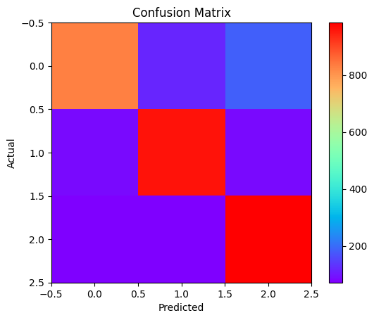

```python
metrics = MulticlassMetrics(predictions.select("prediction", "author_label").rdd)
confusion_matrix = metrics.confusionMatrix().toArray()

# Plot the confusion matrix
plt.figure()
plt.imshow(confusion_matrix, cmap="rainbow")
plt.colorbar()
plt.xlabel("Predicted")
plt.ylabel("Actual")
plt.title("Confusion Matrix")
plt.show()
```

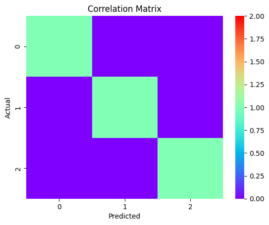

```python
# Correlation matrix
probabilities = predictions.select("probability")

# Convert probabilities to feature vector
assembler = VectorAssembler(inputCols=probabilities.columns, outputCol="features")
assembled_data = assembler.transform(probabilities).select("features")
correlation_matrix = Correlation.corr(assembled_data, "features").collect()[0][0].toArray()

plt.figure()
sns.heatmap(correlation_matrix, cmap="rainbow", vmin=0, vmax=2)
plt.xlabel("Predicted")
plt.ylabel("Actual")
plt.title("Correlation Matrix")
plt.show()
```

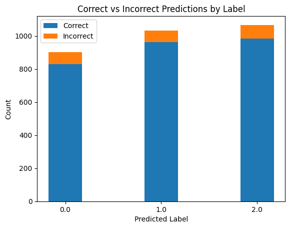

```python
# Extract the labels and counts
label_counts = predictions.groupBy("prediction", "author_label").count().orderBy("prediction", "author_label").collect()
predicted_labels = sorted(set(row["prediction"] for row in label_counts))
actual_labels = sorted(set(row["author_label"] for row in label_counts))

# correct and incorrect count lists
correct_counts = [0] * len(predicted_labels)
incorrect_counts = [0] * len(predicted_labels)

# counts based on the predictions
for row in label_counts:
    pred_label_idx = predicted_labels.index(row["prediction"])
    if row["prediction"] == row["author_label"]:
        correct_counts[pred_label_idx] = row["count"]
    else:
        incorrect_counts[pred_label_idx] = row["count"]

# bar chart
plt.figure()
bar_width = 0.35
index = range(len(predicted_labels))
plt.bar(index, correct_counts, bar_width, label="Correct")
plt.bar(index, incorrect_counts, bar_width, bottom=correct_counts, label="Incorrect")
plt.xlabel("Predicted Label")
plt.ylabel("Count")
plt.title("Correct vs Incorrect Predictions by Label")
plt.xticks(index, predicted_labels)
plt.legend()
plt.show()
```